**Linear Classification**

By Prof. Seungchul Lee  
http://iai.postech.ac.kr/  
Industrial AI Lab at POSTECH

Table of Contents

# 1. Perceptron

## 1.1. Supervised Learning

[figure not shown]

## 1.2. Classification

- where $y$ is a discrete value
  - develop the classification algorithm to determine which class a new input should fall into
- start with binary class problems
  - Later look at multiclass classification problem, although this is just an extension of binary classification
- We could use linear regression
  - Then, threshold the classifier output (i.e. anything over some value is yes, else no)
  - linear regression with thresholding seems to work
- We will learn
  - perceptron
  - support vector machine
  - logistic regression

## 1.3. Perceptron

- For input $x = \begin{bmatrix}x_1\\ \vdots\\ x_d \end{bmatrix}\;$ 'attributes of a customer'
- weights $\omega = \begin{bmatrix}\omega_1\\ \vdots\\ \omega_d \end{bmatrix}$

$$\begin{align*} \text{Approve credit if} \; & \sum\limits_{i=1}^{d}\omega_ix_i > \text{threshold}, \\ \text{Deny credit if} \; & \sum\limits_{i=1}^{d}\omega_ix_i < \text{threshold}. \end{align*}$$

$$h(x) = \text{sign} \left(\left( \sum\limits_{i=1}^{d}\omega_ix_i \right)- \text{threshold} \right) = \text{sign}\left(\left( \sum\limits_{i=1}^{d}\omega_ix_i \right)+ \omega_0\right)$$

- Introduce an artificial coordinate $x_0 = 1$:

$$h(x) = \text{sign}\left( \sum\limits_{i=0}^{d}\omega_ix_i \right)$$

- In vector form, the perceptron implements

$$h(x) = \text{sign}\left( \omega^T x \right)$$

[figure not shown]

- Hyperplane
  - Separates a D-dimensional space into two half-spaces
  - Defined by an outward pointing normal vector $\omega$
  - $\omega$ is orthogonal to any vector lying on the hyperplane
  - assume the hyperplane passes through origin, $\omega^T x = 0$ with $x_0 = 1$

[figure not shown]

### 1.3.1. Sign

- Sign with respect to a line

$$ \omega = \begin{bmatrix} \omega_{1} \\ \omega_{2} \end{bmatrix}, \quad x = \begin{bmatrix} x_{1} \\ x_{2}\end{bmatrix} \quad\implies\quad g(x) = \omega_{1}x_{1} + \omega_{2}x_{2} + \omega_{0} = \omega^{T}x + \omega_{0}\\ \omega = \begin{bmatrix} \omega_{0} \\ \omega_{1} \\ \omega_{2} \end{bmatrix}, \quad x = \begin{bmatrix} 1 \\ x_{1} \\ x_{2}\end{bmatrix} \quad\implies\quad g(x) = \omega_{0} + \omega_{1}x_{1} + \omega_{2}x_{2} = \omega^{T}x $$

[figure not shown]

### 1.3.2. How to Find $\omega$

- All data in class 1
  - g(x) > 0
- All data in class 0
  - g(x) < 0

[figure not shown]

### 1.3.2. Perceptron Algorithm

The perceptron implements

$$h(x) = \text{sign}\left( \omega^Tx \right)$$

Given the training set

$$(x_1, y_1), (x_2, y_2), \cdots, (x_N, y_N) \quad \text{where } y_i \in \{-1,1\}$$

1) pick a misclassified point

$$ \text{sign}\left(\omega^Tx_n \right) \neq y_n$$

2) and update the weight vector

$$\omega \leftarrow \omega + y_nx_n$$

[figure not shown]

**Why perceptron updates work ?**

- Let's look at a misclassified positive example ($y_n = +1$)
  - perceptron (wrongly) thinks $\omega_{old}^T x_n < 0$
- updates would be $$ \begin{align*}\omega_{new} &= \omega_{old} + y_n x_n = \omega_{old} + x_n \\ \\ \omega_{new}^T x_n &= (\omega_{old} + x_n)^T x_n = \omega_{old}^T x_n + x_n^T x_n \end{align*}$$
- Thus $\omega_{new}^T x_n$ is less negative than $\omega_{old}^T x_n$

### 1.3.5. The best hyperplane separator?

- Perceptron finds one of the many possible hyperplanes separating the data if one exists
- Of the many possible choices, which one is the best?
- Utilize distance information as well
- Intuitively we want the hyperplane having the maximum margin
- Large margin leads to good generalization on the test data
  - we will see this formally when we cover Support Vector Machine

### 1.3.6. Python Example

$$ \begin{align*} \omega &= \begin{bmatrix} \omega_1 \\ \omega_2 \\ \omega_3\end{bmatrix}\\ x &= \begin{bmatrix} \left(x^{(1)}\right)^T \\ \left(x^{(2)}\right)^T \\ \left(x^{(3)}\right)^T\\ \vdots \\ \left(x^{(m)}\right)^T \end{bmatrix} = \begin{bmatrix} 1 & x_1^{(1)} & x_2^{(1)} \\ 1 & x_1^{(2)} & x_2^{(2)} \\ 1 & x_1^{(3)} & x_2^{(3)}\\\vdots & \vdots & \vdots \\ 1 & x_1^{(m)} & x_2^{(m)}\end{bmatrix} \\ y &= \begin{bmatrix}y^{(1)} \\ y^{(2)} \\ y^{(3)}\\ \vdots \\ y^{(m)} \end{bmatrix} \end{align*}$$

```python
import numpy as np
import matplotlib.pyplot as plt

% matplotlib inline
```

```python
#training data gerneration
m = 100
x1 = 8*np.random.rand(m, 1)
x2 = 7*np.random.rand(m, 1) - 4

g0 = 0.8*x1 + x2 - 3
g1 = g0 - 1
g2 = g0 + 1
```

```python
C1 = np.where(g1 >= 0)
C2 = np.where(g2 < 0)
print(C1)
```

```
(array([ 0,  2,  6, 10, 11, 12, 14, 15, 18, 20, 21, 22, 23, 32, 33, 34, 35,
       37, 39, 40, 41, 45, 47, 48, 54, 60, 61, 63, 66, 67, 71, 72, 78, 81,
       82, 86, 89], dtype=int64), array([0, 0, 0, 0, 0, 0, 0, 0, 0, 0, 0, 0, 0, 0, 0, 0, 0, 0, 0, 0, 0, 0,
       0, 0, 0, 0, 0, 0, 0, 0, 0, 0, 0, 0, 0, 0, 0], dtype=int64))
```

```python
C1 = np.where(g1 >= 0)[0]
C2 = np.where(g2 < 0)[0]
print(C1.shape)
print(C2.shape)
```

```
(37,)
(34,)
```

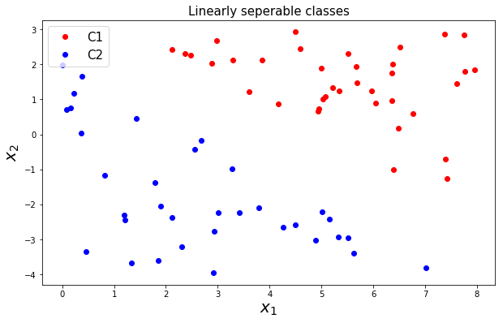

```python
plt.figure(figsize=(10, 6))
plt.plot(x1[C1], x2[C1], 'ro', label='C1')
plt.plot(x1[C2], x2[C2], 'bo', label='C2')
plt.title('Linearly seperable classes', fontsize=15)
plt.legend(loc='upper left', fontsize=15)
plt.xlabel(r'$x_1$', fontsize=20)
plt.ylabel(r'$x_2$', fontsize=20)
plt.show()
```

$$ \begin{align*} x &= \begin{bmatrix} \left(x^{(1)}\right)^T \\ \left(x^{(2)}\right)^T \\ \left(x^{(3)}\right)^T\\ \vdots \\ \left(x^{(m)}\right)^T \end{bmatrix} = \begin{bmatrix} 1 & x_1^{(1)} & x_2^{(1)} \\ 1 & x_1^{(2)} & x_2^{(2)} \\ 1 & x_1^{(3)} & x_2^{(3)}\\\vdots & \vdots & \vdots \\ 1 & x_1^{(m)} & x_2^{(m)}\end{bmatrix} \\ y &= \begin{bmatrix}y^{(1)} \\ y^{(2)} \\ y^{(3)}\\ \vdots \\ y^{(m)} \end{bmatrix} \end{align*}$$

```python
X1 = np.hstack([np.ones([C1.shape[0],1]), x1[C1], x2[C1]])
X2 = np.hstack([np.ones([C2.shape[0],1]), x1[C2], x2[C2]])
X = np.vstack([X1, X2])

y = np.vstack([np.ones([C1.shape[0],1]), -np.ones([C2.shape[0],1])])

X = np.asmatrix(X)
y = np.asmatrix(y)
```

$$\omega = \begin{bmatrix} \omega_1 \\ \omega_2 \\ \omega_3\end{bmatrix}$$$$\omega \leftarrow \omega + yx$$

where $(x, y)$ is a misclassified training point

```python
w = np.ones([3,1])
w = np.asmatrix(w)

n_iter = y.shape[0]
for k in range(n_iter):
    for i in range(n_iter):
        if y[i,0] != np.sign(X[i,:]*w)[0,0]:
            w += y[i,0]*X[i,:].T

print(w)
```

```
[[-11.        ]
 [  3.01590965]
 [  3.10355604]]
```

$$ \begin{align*} g(x) &= \omega^Tx + \omega_0 = \omega_1x_1 + \omega_2x_2 + \omega_0 = 0 \\ \implies x_2 &= -\frac{\omega_1}{\omega_2} x_1 - \frac{\omega_0}{\omega_2} \end{align*} $$

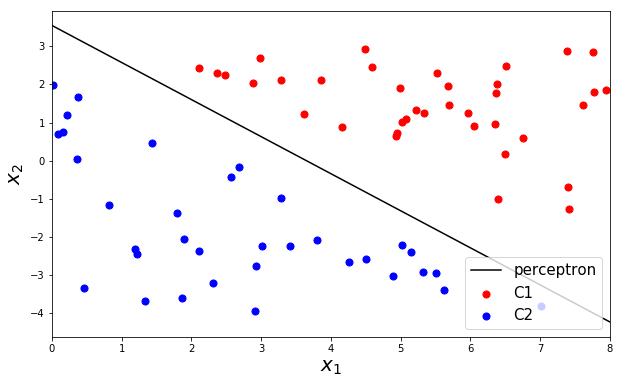

```python
x1p = np.linspace(0,8,100).reshape(-1,1)
x2p = - w[1,0]/w[2,0]*x1p - w[0,0]/w[2,0]

plt.figure(figsize=(10, 6))
plt.scatter(x1[C1], x2[C1], c='r', s=50, label='C1')
plt.scatter(x1[C2], x2[C2], c='b', s=50, label='C2')
plt.plot(x1p, x2p, c='k', label='perceptron')
plt.xlim([0,8])
plt.xlabel('$x_1$', fontsize = 20)
plt.ylabel('$x_2$', fontsize = 20)
plt.legend(loc = 4, fontsize = 15)
plt.show()
```

**Exercise**

```python
#training data gerneration
m = 100
x1 = 5*np.random.rand(m, 1)
x2 = 6*np.random.rand(m, 1) - 4

g0 = 0.5*x1 + 2*x2 - 1
g1 = g0 - 1
g2 = g0 + 1
```

```python
# solution

C1 = np.where(g1 >= 0)[0]
C2 = np.where(g2 < 0)[0]
print(C1.shape)
print(C2.shape)

X1 = np.hstack([np.ones([C1.shape[0],1]), x1[C1], x2[C1]])
X2 = np.hstack([np.ones([C2.shape[0],1]), x1[C2], x2[C2]])
X = np.vstack([X1, X2])

y = np.vstack([np.ones([C1.shape[0],1]), -np.ones([C2.shape[0],1])])

X = np.asmatrix(X)
y = np.asmatrix(y)

w = np.ones([3,1])
w = np.asmatrix(w)

n_iter = y.shape[0]
for k in range(n_iter):
    for i in range(n_iter):
        if y[i,0] != np.sign(X[i,:]*w)[0,0]:
            w += y[i,0]*X[i,:].T

print(w)
```

```
(29,)
(50,)
[[ 1.        ]
 [-0.35319979]
 [ 3.24167894]]
```

# 2. Support Vector Machine

## 2.1. Distance Between Two Lines

- To find a distance between $g(x) = -1$ and $g(x) = 1$
- Suppose $g(x_1) = -1,\; g(x_2) = 1$

$$ \begin{array}{I} \omega^Tx_1+\omega_0 = -1\\ \omega^Tx_2+\omega_0 = 1\\ \end{array} \; \implies \; \omega^T(x_2 - x_1) = 2$$

$$s = \left\langle\frac{\omega}{\lVert \omega \rVert}, x_2 - x_1 \right\rangle = \frac{1}{\lVert \omega \rVert}\omega^T(x_2 - x_1) = \frac {2}{\lVert \omega \rVert}$$

[figure not shown]

## 2.2. Illustrative Example

- Binary classification
  - $C_1$ and $C_2$
- Features
  - The coordinate of the unknown animal $i$ in the zoo

$$x = \begin{bmatrix}x_1 \\ x_2 \end{bmatrix}$$

[figure not shown]

- Is it possible to distinguish between $C_1$ and $C_2$ by its coordinates on a map of the zoo?
- We need to find a separating hyperplane (or a line in 2D)

$$ \omega_1x_1 + \omega_2x_2 + \omega_0 = 0 $$

$$ \begin{bmatrix}\omega_1 & \omega_2 \end{bmatrix} \begin{bmatrix}x_1 \\ x_2 \end{bmatrix} + \omega_0 = 0$$$$ \omega^Tx + \omega_0 = 0$$

```python
import numpy as np
import matplotlib.pyplot as plt
%matplotlib inline

#training data gerneration
x1 = 8*np.random.rand(100, 1)
x2 = 7*np.random.rand(100, 1) - 4

g0 = 0.8*x1 + x2 - 3
g1 = g0 - 1
g2 = g0 + 1

C1 = np.where(g1 >= 0)[0]
C2 = np.where(g2 < 0)[0]
```

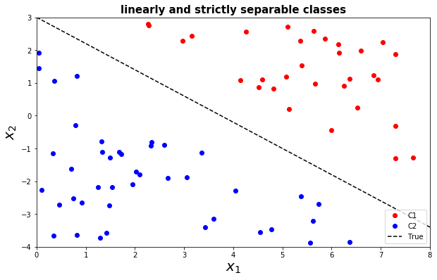

```python
xp = np.linspace(0,8,100).reshape(-1,1)
ypt = -0.8*xp + 3

plt.figure(figsize=(10, 6))
plt.plot(x1[C1], x2[C1], 'ro', label='C1')
plt.plot(x1[C2], x2[C2], 'bo', label='C2')
plt.plot(xp, ypt, '--k', label='True')
plt.title('linearly and strictly separable classes', fontweight = 'bold', fontsize = 15)
plt.xlabel('$x_1$', fontsize = 20)
plt.ylabel('$x_2$', fontsize = 20)
plt.legend(loc = 4)
plt.xlim([0, 8])
plt.ylim([-4, 3])
plt.show()
```

- Given:
  - Hyperplane defined by $\omega$ and $\omega_0$
  - Animals coordinates (or features) $x$
- Decision making:

$$ \omega^Tx + \omega_0 >0 \implies x \; \text{belongs to} \; C_1$$$$ \omega^Tx + \omega_0 <0 \implies x \; \text{belongs to} \; C_2$$

- Find $\omega$ and $\omega_0$ such that $x$ given $\omega^Tx + \omega_0 = 0$

  or
- Find $\omega$ and $\omega_0$ such that $x\in C_1$ given $\omega^Tx + \omega_0 >1$ and $x\in C_2$ given $\omega^Tx + \omega_0 < -1$

$$ \begin{align*} \;&\omega^Tx + \omega_0 > b \\ \Longleftrightarrow \;&\frac{\omega^T}{b}x + \frac{\omega_0}{b} > 1 \\ \Longleftrightarrow \;&\omega'^Tx + \omega'_0 > 1 \end{align*}$$

- Same problem if strictly separable

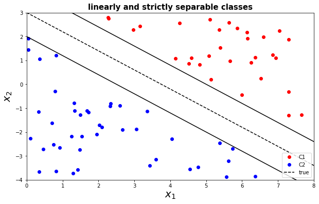

```python
#  see how data are generated
xp = np.linspace(0,8,100).reshape(-1,1)
ypt = -0.8*xp + 3

plt.figure(figsize=(10, 6))
plt.plot(x1[C1], x2[C1], 'ro', label='C1')
plt.plot(x1[C2], x2[C2], 'bo', label='C2')
plt.plot(xp, ypt, '--k', label='true')
plt.plot(xp, ypt-1, '-k')
plt.plot(xp, ypt+1, '-k')
plt.title('linearly and strictly separable classes', fontweight = 'bold', fontsize = 15)
plt.xlabel('$x_1$', fontsize = 20)
plt.ylabel('$x_2$', fontsize = 20)
plt.legend(loc = 4)
plt.xlim([0, 8])
plt.ylim([-4, 3])
plt.show()
```

### 2.2.1. Optimization Formulation 1

- $n \;(=2)$ features
- $m = N + M$ data points in training set

$$ x^{(i)} = \begin{bmatrix} x^{(i)}_1 \\ x^{(i)}_2 \end{bmatrix} \;\text{with}\; \omega = \begin{bmatrix} \omega_1 \\ \omega_2 \end{bmatrix}\qquad \text{or} \qquad x^{(i)} = \begin{bmatrix} 1 \\ x^{(i)}_1 \\ x^{(i)}_2 \end{bmatrix} \;\; \text{with}\; \omega = \begin{bmatrix} \omega_0 \\ \omega_1 \\ \omega_2 \end{bmatrix}$$

- $N$ belongs to $C_1$ in training set
- $M$ belongs to $C_2$ in training set
- $\omega$ and $\omega_0$ are the unknown variables

$$\begin{align*} \text{minimize} \quad & \text{something} \\ \\ \text{subject to} \quad & \begin{cases} \omega^Tx^{(1)} + \omega_0 \geq1\\ \omega^Tx^{(2)} + \omega_0 \geq1\\ \quad \quad \vdots \\ \omega^Tx^{(N)} + \omega_0 \geq1\\ \end{cases} \\ & \begin{cases} \omega^Tx^{(N+1)} + \omega_0 \leq{-1}\\ \omega^Tx^{(N+2)} + \omega_0 \leq{-1}\\ \quad \quad \vdots \\ \omega^Tx^{(N+M)} + \omega_0 \leq{-1}\\ \end{cases} \end{align*}$$

$$\begin{align*} \text{minimize} \quad & \text{something} \\ \\ \text{subject to} \quad & \begin{cases} \omega^Tx^{(1)} \geq1\\ \omega^Tx^{(2)} \geq1\\ \quad \quad \vdots \\ \omega^Tx^{(N)} \geq1\\ \end{cases} \\ & \begin{cases} \omega^Tx^{(N+1)} \leq{-1}\\ \omega^Tx^{(N+2)} \leq{-1}\\ \quad \quad \vdots \\ \omega^Tx^{(N+M)} \leq{-1}\\ \end{cases} \end{align*}$$

**Code (CVXPY)**

$$ \begin{align*} &X_1 = \begin{bmatrix} \left(x^{(1)}\right)^T \\ \left(x^{(2)}\right)^T \\ \vdots \\ \left(x^{(N)}\right)^T\end{bmatrix} = \begin{bmatrix} x_1^{(1)} & x_2^{(1)} \\ x_1^{(2)} & x_2^{(2)} \\ \vdots & \vdots \\ x_1^{(N)} & x_2^{(N)} \\ \end{bmatrix}\\ &X_2 = \begin{bmatrix} \left(x^{(N+1)}\right)^T \\ \left(x^{(N+2)}\right)^T \\ \vdots \\ \left(x^{(N+M)}\right)^T\end{bmatrix} = \begin{bmatrix} x_1^{(N+1)} & x_2^{(N+1)} \\ x_1^{(N+2)} & x_2^{(N+2)} \\ \vdots & \vdots \\ x_1^{(N+M)} & x_2^{(N+M)} \\ \end{bmatrix}\end{align*}$$

$$ \begin{align*} &X_1 = \begin{bmatrix} \left(x^{(1)}\right)^T \\ \left(x^{(2)}\right)^T \\ \vdots \\ \left(x^{(N)}\right)^T\end{bmatrix} = \begin{bmatrix} 1 & x_1^{(1)} & x_2^{(1)} \\ 1 & x_1^{(2)} & x_2^{(2)} \\ \vdots & \vdots & \vdots \\ 1 & x_1^{(N)} & x_2^{(N)} \\ \end{bmatrix}\\ &X_2 = \begin{bmatrix} \left(x^{(N+1)}\right)^T \\ \left(x^{(N+2)}\right)^T \\ \vdots \\ \left(x^{(N+M)}\right)^T\end{bmatrix} = \begin{bmatrix} 1 & x_1^{(N+1)} & x_2^{(N+1)} \\ 1 & x_1^{(N+2)} & x_2^{(N+2)} \\ \vdots & \vdots & \vdots \\ 1 & x_1^{(N+M)} & x_2^{(N+M)} \\ \end{bmatrix}\end{align*}$$

| $$\begin{align*} \text{minimize} \quad & \text{something} \\ \text{subject to} \quad & X_1\omega + \omega_0 \geq 1 \\ & X_2\omega + \omega_0 \leq -1 \end{align*}$$ | $$\begin{align*} \text{minimize} \quad & \text{something} \\ \text{subject to} \quad & X_1\omega \geq 1 \\ & X_2\omega \leq -1 \end{align*}$$ |
| --- | --- |

**Optimization Formulation 1**

$$\begin{align*} \text{minimize} \quad & \text{something} \\ \text{subject to} \quad & X_1\omega \geq 1 \\ & X_2\omega \leq -1 \end{align*}$$

```python
import cvxpy as cvx

N = C1.shape[0]
M = C2.shape[0]

X1 = np.hstack([np.ones([N,1]), x1[C1], x2[C1]])
X2 = np.hstack([np.ones([M,1]), x1[C2], x2[C2]])

X1 = np.asmatrix(X1)
X2 = np.asmatrix(X2)
```

```python
w = cvx.Variable(3,1)
obj = cvx.Minimize(1)
const = [X1*w >= 1, X2*w <= -1]
prob = cvx.Problem(obj, const).solve()

w = w.value
```

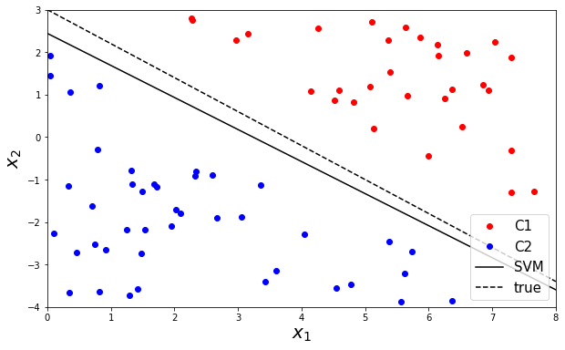

```python
xp = np.linspace(0,8,100).reshape(-1,1)
yp = - w[1,0]/w[2,0]*xp - w[0,0]/w[2,0]

plt.figure(figsize=(10, 6))
plt.plot(X1[:,1], X1[:,2], 'ro', label='C1')
plt.plot(X2[:,1], X2[:,2], 'bo', label='C2')
plt.plot(xp, yp, 'k', label='SVM')
plt.plot(xp, ypt, '--k', label='true')
plt.xlim([0,8])
plt.ylim([-4,3])
plt.xlabel('$x_1$', fontsize = 20)
plt.ylabel('$x_2$', fontsize = 20)
plt.legend(loc = 4, fontsize = 15)
plt.show()
```

### 2.2.2. Outlier

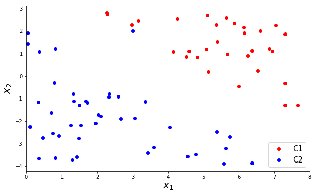

```python
X1 = np.hstack([np.ones([N,1]), x1[C1], x2[C1]])
X2 = np.hstack([np.ones([M,1]), x1[C2], x2[C2]])

outlier = np.array([1, 3, 2]).reshape(-1,1)
X2 = np.vstack([X2, outlier.T])

X1 = np.asmatrix(X1)
X2 = np.asmatrix(X2)

plt.figure(figsize=(10, 6))
plt.plot(X1[:,1], X1[:,2], 'ro', label='C1')
plt.plot(X2[:,1], X2[:,2], 'bo', label='C2')
plt.xlim([0,8])
plt.xlabel('$x_1$', fontsize = 20)
plt.ylabel('$x_2$', fontsize = 20)
plt.legend(loc = 4, fontsize = 15)
plt.show()
```

```python
w = cvx.Variable(3,1)
obj = cvx.Minimize(1)
const = [X1*w >= 1, X2*w <= -1]
prob = cvx.Problem(obj, const).solve()

print(w.value)
```

```
[[-301.76470598]
 [  57.4836777 ]
 [  63.49876263]]
```

### 2.2.3. Optimization Formulation 2

- $n \;(=2)$ features
- $m = N+M$ data points in a training set

$$x^i = \begin{bmatrix} x_1^{(i)} \\ x_2^{(i)} \end{bmatrix}$$

- $N$ belongs to $C_1$ in training set
- $M$ belongs to $C_2$ in training set
- $\omega$ and $\omega_0$ are the variables (unknown)
- For the non-separable case, we relax the above constraints
- Need slack variables $u$ and $\upsilon$ where all are positive

**The optimization problem for the non-separable case**

$$\begin{align*} \text{minimize} \quad & \sum\limits_{i=1}^{N}u_i + \sum\limits_{i=1}^{M}\upsilon_i \\ \\ \text{subject to} \quad & \begin{cases} \omega^Tx^{(1)} + \omega_0 \geq1-u_1\\ \omega^Tx^{(2)} + \omega_0 \geq1-u_2\\ \quad \quad \vdots \\ \omega^Tx^{(N)} + \omega_0 \geq1-u_N\\ \end{cases} \\ & \begin{cases} \omega^Tx^{(N+1)} + \omega_0 \leq{-(1-\upsilon_1)}\\ \omega^Tx^{(N+2)} + \omega_0 \leq{-(1-\upsilon_2)}\\ \quad \quad \vdots \\ \omega^Tx^{(N+M)} + \omega_0 \leq{-(1-\upsilon_M)}\\ \end{cases} \\ & \begin{cases} u \geq 0\\ v \geq 0\\ \end{cases} \end{align*}$$

- Expressed in a matrix form

$$ \begin{align*} X_1 &= \begin{bmatrix} x^{(1)^T} \\ x^{(2)^T} \\ \vdots \\ x^{(N)^T}\end{bmatrix} = \begin{bmatrix} x_1^{(1)} & x_2^{(1)} \\ x_1^{(2)} & x_2^{(2)} \\ \vdots & \vdots \\ x_1^{(N)} & x_2^{(N)} \\ \end{bmatrix}\\ X_2 &= \begin{bmatrix} x^{(N+1)^T} \\ x^{(N+2)^T} \\ \vdots \\ x^{(N+M)^T}\end{bmatrix} = \begin{bmatrix} x_1^{(N+1)} & x_2^{(N+1)} \\ x_1^{(N+2)} & x_2^{(N+2)} \\ \vdots & \vdots \\ x_1^{(N+M)} & x_2^{(N+M)} \\ \end{bmatrix} \\ u &= \begin{bmatrix} u_1\\ \vdots\\ u_N\\ \end{bmatrix}\\ \upsilon &= \begin{bmatrix} \upsilon_{1}\\ \vdots\\ \upsilon_{M}\\ \end{bmatrix} \end{align*}$$

$$ \begin{align*} X_1 &= \begin{bmatrix} \left(x^{(1)}\right)^T \\ \left(x^{(2)}\right)^T \\ \vdots \\ \left(x^{(N)}\right)^T\end{bmatrix} = \begin{bmatrix} 1 & x_1^{(1)} & x_2^{(1)} \\ 1 & x_1^{(2)} & x_2^{(2)} \\ \vdots & \vdots & \vdots \\ 1 & x_1^{(N)} & x_2^{(N)} \\ \end{bmatrix}\\ X_2 &= \begin{bmatrix} \left(x^{(N+1)}\right)^T \\ \left(x^{(N+2)}\right)^T \\ \vdots \\ \left(x^{(N+M)}\right)^T\end{bmatrix} = \begin{bmatrix} 1 & x_1^{(N+1)} & x_2^{(N+1)} \\ 1 & x_1^{(N+2)} & x_2^{(N+2)} \\ \vdots & \vdots & \vdots \\ 1 & x_1^{(N+M)} & x_2^{(N+M)} \\ \end{bmatrix} \\ u &= \begin{bmatrix} u_1\\ \vdots\\ u_N\\ \end{bmatrix}\\ \upsilon &= \begin{bmatrix} \upsilon_{1}\\ \vdots\\ \upsilon_{M}\\ \end{bmatrix} \end{align*}$$

$$\begin{align*} \text{minimize} \quad & 1^Tu + 1^T\upsilon \\ \text{subject to} \quad & X_1\omega + \omega_0 \geq 1-u \\ & X_2\omega + \omega_0 \leq -(1-\upsilon) \\ & u \geq 0 \\ & \upsilon \geq 0 \end{align*}$$

$$\begin{align*} \text{minimize} \quad & 1^Tu + 1^T\upsilon \\ \text{subject to} \quad & X_1\omega \geq 1-u \\ & X_2\omega \leq -(1-\upsilon) \\ & u \geq 0 \\ & \upsilon \geq 0 \end{align*}$$

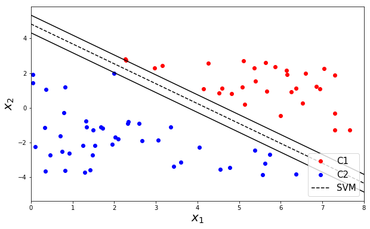

```python
X1 = np.hstack([np.ones([C1.shape[0],1]), x1[C1], x2[C1]])
X2 = np.hstack([np.ones([C2.shape[0],1]), x1[C2], x2[C2]])

outlier = np.array([1, 2, 2]).reshape(-1,1)
X2 = np.vstack([X2, outlier.T])

X1 = np.asmatrix(X1)
X2 = np.asmatrix(X2)

N = X1.shape[0]
M = X2.shape[0]

w = cvx.Variable(3,1)
u = cvx.Variable(N,1)
v = cvx.Variable(M,1)
obj = cvx.Minimize(np.ones((1,N))*u + np.ones((1,M))*v)
const = [X1*w >= 1-u, X2*w <= -(1-v), u >= 0, v >= 0 ]
prob = cvx.Problem(obj, const).solve()

w = w.value

xp = np.linspace(0,8,100).reshape(-1,1)
yp = - w[1,0]/w[2,0]*xp - w[0,0]/w[2,0]

plt.figure(figsize=(10, 6))
plt.plot(X1[:,1], X1[:,2], 'ro', label='C1')
plt.plot(X2[:,1], X2[:,2], 'bo', label='C2')
plt.plot(xp, yp, '--k', label='SVM')
plt.plot(xp, yp-1/w[2,0], '-k')
plt.plot(xp, yp+1/w[2,0], '-k')
plt.xlim([0,8])
plt.xlabel('$x_1$', fontsize = 20)
plt.ylabel('$x_2$', fontsize = 20)
plt.legend(loc = 4, fontsize = 15)
plt.show()
```

**Further improvement**

- Notice that hyperplane is not as accurately represent the division due to the outlier
- Can we do better when there are noise data or outliers?
- Yes, but we need to look beyond linear programming (LP)
- Idea: large margin leads to good generalization on the test data

### 2.2.4. Maximize Margin (Finally, it is Support Vector Machine)

- Distance (= margin)

$$\text{margin} = \frac{2}{\lVert \omega \rVert _2}$$

[figure not shown]

- Minimize $\lVert \omega \rVert_2$ to maximize the margin
- Multiple objectives
- Use gamma ($\gamma$) as a weighting betwwen the followings:
  - Bigger margin given robustness to outliers
  - Hyperplane that has few (or no) errors

$$\begin{align*} \text{minimize} \quad & \lVert \omega \rVert_2 + \gamma(1^Tu + 1^T\upsilon) \\ \text{subject to} \quad & X_1\omega \geq 1-u \\ & X_2\omega \leq -(1-\upsilon) \\ & u \geq 0 \\ & \upsilon \geq 0 \end{align*}$$

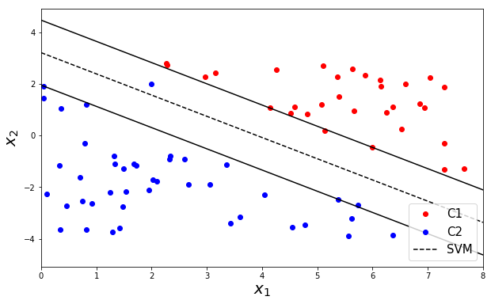

```python
X1 = np.hstack([np.ones([C1.shape[0],1]), x1[C1], x2[C1]])
X2 = np.hstack([np.ones([C2.shape[0],1]), x1[C2], x2[C2]])

outlier = np.array([1, 2, 2]).reshape(-1,1)
X2 = np.vstack([X2, outlier.T])

X1 = np.asmatrix(X1)
X2 = np.asmatrix(X2)

N = X1.shape[0]
M = X2.shape[0]

g = 1
w = cvx.Variable(3,1)
u = cvx.Variable(N,1)
v = cvx.Variable(M,1)
obj = cvx.Minimize(cvx.norm(w,2) + g*(np.ones((1,N))*u + np.ones((1,M))*v))
const = [X1*w >= 1-u, X2*w <= -(1-v), u >= 0, v >= 0 ]
prob = cvx.Problem(obj, const).solve()

w = w.value

xp = np.linspace(0,8,100).reshape(-1,1)
yp = - w[1,0]/w[2,0]*xp - w[0,0]/w[2,0]

plt.figure(figsize=(10, 6))
plt.plot(X1[:,1], X1[:,2], 'ro', label='C1')
plt.plot(X2[:,1], X2[:,2], 'bo', label='C2')
plt.plot(xp, yp, '--k', label='SVM')
plt.plot(xp, yp-1/w[2,0], '-k')
plt.plot(xp, yp+1/w[2,0], '-k')
plt.xlim([0,8])
plt.xlabel('$x_1$', fontsize = 20)
plt.ylabel('$x_2$', fontsize = 20)
plt.legend(loc = 4, fontsize = 15)
plt.show()
```

### 2.2.5. Support Vector Machine

- Probably the most popular/influential classification algorithm
- A hyperplane based classifier (like the Perceptron)
- Additionally uses the maximum margin principle
  - maximize distance (margin) of closest samples from the decision line
    $$ \text{maximize {minimum distance}} $$
  - note: perceptron only utilizes a sign of distance
  - Finds the hyperplane with maximum separation margin on the training data

$$\begin{align*} \text{minimize} \quad & \lVert \omega \rVert_2 + \gamma(1^Tu + 1^T\upsilon) \\ \text{subject to} \quad & X_1\omega \geq 1-u \\ & X_2\omega \leq -(1-\upsilon) \\ & u \geq 0 \\ & \nu \geq 0 \end{align*}$$

**Exercise**

In this problem, we will try to classify handwritten digits. For the sake of simplicity, we simplify this digit classification problem into a binary classification between digit 0 and digit 1.

You can download images from this [link](https://www.dropbox.com/sh/c4dcm6reypvs58s/AADTUM4jXHPQl9w-OAdUj-Eda?dl=1).

1) Load data

You can load the digit images using the below code. Each dataset contains 1000 gray-scaled images with size of (28, 28).

```python
from six.moves import cPickle
digit0 = cPickle.load(open('./data/data0.pkl', 'rb'))
digit1 = cPickle.load(open('./data/data1.pkl', 'rb'))
```

```python
# Check the shape of each dataset. Randomly pick images from each datasets and imshow the images.

print(digit0.shape, digit1.shape)
```

```
(784000,) (1000, 28, 28)
```

```python
digit0 = np.reshape(digit0, [-1, 28, 28])
digit0.shape
```

```
(1000, 28, 28)
```

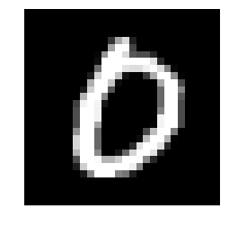

```python
c = np.random.randint(0, 1000)
plt.imshow(digit0[c,:],'gray')
plt.axis('off')
plt.show()
```

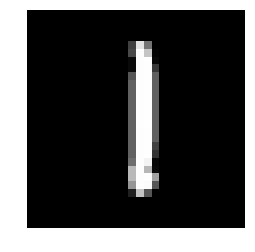

```python
plt.imshow(digit1[c,:],'gray')
plt.axis('off')
plt.show()
```

2) Extract features

[figure not shown]

**(a)** Write the code for feature extraction. We will construct the feature vectors for each dataset with the following three features :

- The average value of pixels located at the center of the image ([9:18, 9:18])
- The average value of pixels over the entire location
- Include the ones as the bias term

**(b)** Then you will have (1000, 3) feature vectors for each dataset. Plot the first two features for every samples on the 2D-plane.

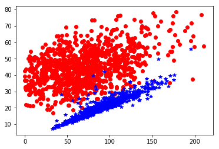

```python
A = np.empty((digit0.shape[0],3))
B = np.empty((digit1.shape[0],3))

for i in range (digit0.shape[0]):
    A[i][0] = np.array([np.array(digit0[i,9:18,9:18]).mean()])
    A[i][1] = np.array([np.array(digit0[i,:,:]).mean()])
    A[i][2] = 1

for i in range (digit1.shape[0]):
    B[i][0] = np.array([np.array(digit1[i,9:18,9:18]).mean()])
    B[i][1] = np.array([np.array(digit1[i,:,:]).mean()])
    B[i][2] = 1

x0 = np.asmatrix(A[:,0]).reshape(-1,1)
y0 = np.asmatrix(A[:,1]).reshape(-1,1)

x1 = np.asmatrix(B[:,0]).reshape(-1,1)
y1 = np.asmatrix(B[:,1]).reshape(-1,1)

plt.plot(x0, y0, 'o', color = 'r')
plt.plot(x1, y1, '*', color = 'b')
plt.show()
```

3) Write the code to classify the digits with SVM using cvxpy and plot the decision boundary of your classifier on the figure you have plotted in Step 2 of the above exercise.

**solution**

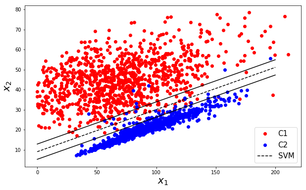

```python
X1 = np.hstack([np.ones((1000,1)), x0, y0])
X2 = np.hstack([np.ones((1000,1)), x1, y1])

X1 = np.asmatrix(X1)
X2 = np.asmatrix(X2)

g=1
z=cvx.Variable(3,1)
u=cvx.Variable(1000,1)
v=cvx.Variable(1000,1)

obj = cvx.Minimize(cvx.norm(z,2)+g*(np.ones((1,1000))*u + np.ones((1,1000))*v))
const = [X1*z >= 1-u, X2*z <= -(1-v), u >= 0, v >= 0 ]
prob = cvx.Problem(obj, const).solve()

z=z.value

xp = np.linspace(0,200,100).reshape(-1,1)
yp = - z[1,0]/z[2,0]*xp - z[0,0]/z[2,0]

plt.figure(figsize=(10, 6))
plt.plot(X1[:,1], X1[:,2], 'ro', label='C1')
plt.plot(X2[:,1], X2[:,2], 'bo', label='C2')
plt.plot(xp, yp, '--k', label='SVM')
plt.plot(xp, yp-1/z[2,0], '-k')
plt.plot(xp, yp+1/z[2,0], '-k')

plt.xlabel('$x_1$', fontsize = 20)
plt.ylabel('$x_2$', fontsize = 20)
plt.legend(loc = 4, fontsize = 15)
plt.show()
```

# 3. Logistic Regression

- Logistic regression is a classification algorithm - don't be confused

## 3.1. Using all Distances

- Perceptron: make use of sign of data
- SVM: make use of margin (minimum distance)
- We want to use *distance information of all data points* $\rightarrow$ logistic regression
- basic idea: to find the decision boundary (hyperplane) of $g(x)=\omega^T x =0$ such that maximizes $\prod_i \lvert h_i \rvert$

[figure not shown]

- Inequality of arithmetic and geometric means

$$ \frac{x_{1} + x_{2} + \cdots + x_{m}}{m} \geq \sqrt[m]{x_{1} \cdot x_{2} \cdots x_{m}} \quad \text{ and that equality holds if and only if } x_{1} = x_{2} = \cdots = x_{m}$$

- Roughly speaking, this optimization of $\max \prod_i \lvert h_i \rvert$ tends to position a hyperplane in the middle of two classes

$$h = \frac{g(x)}{\lVert \omega \rVert} = \frac{\omega^T x}{\lVert \omega \rVert} \sim \omega^T x$$

- SVM vs. Logistic Regression

[figure not shown]

$$\hspace{2em} SVM \qquad \qquad \qquad \qquad \qquad Logistic \, Regression$$

- We link or squeeze $(-\infty, +\infty)$ to $(0,1)$ for several reasons:

[figure not shown]

- If $\sigma(z)$ is the sigmoid function, or the logistic function $$ \sigma(z) = \frac{1}{1+e^{-z}} \implies \sigma(\omega^T x) = \frac{1}{1+e^{-\omega^T x}}$$
  - logistic function always generates a value between 0 and 1
  - Crosses 0.5 at the origin, then flattens out

```python
import numpy as np
import matplotlib.pyplot as plt

%matplotlib inline
```

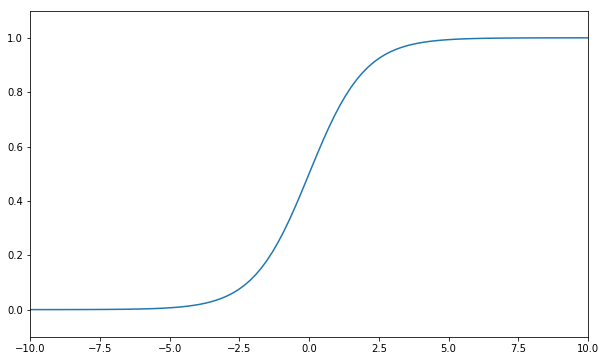

```python
z = np.linspace(-10,10,100)
s = 1/(1+np.exp(-z))

plt.figure(figsize=(10,6))
plt.plot(z, s)
plt.xlim([-10, 10])
plt.ylim([-0.1, 1.1])
plt.show()
```

- Benefit of mapping via the logistic function
  - monotonic: same or similar optimziation solution
  - continuous and differentiable: good for gradient descent optimization
  - probability or confidence: can be considered as probability

  $$P\left(y = +1 \mid x,\omega\right) = \frac{1}{1+e^{-\omega^T x}} \;\; \in \; [0,1]$$
  - Often we do note care about predicting the label $y$
  - Rather, we want to predict the label probabilities $P\left(y \mid x,\omega\right)$
    - the probability that the label is $+1$ $$P\left(y = +1 \mid x,\omega\right)$$
    - the probability that the label is $0$ $$P\left(y = 0 \mid x,\omega\right) = 1 - P\left(y = +1 \mid x,\omega\right)$$
- Goal: we need to fit $\omega$ to our data

## 3.2. Probabilistic Approach (or MLE)

Consider a random variable $ y \in \{0, 1\} $

$$P(y=+1) = p, \quad P(y=0) = 1-p$$

where $ p \in [0, 1]$, and is assumed to depend on a vector of explanatory variables $x \in \mathbb{R}^n$

Then, the logistic model has the form

$$ \begin{align*} p &= \frac{1}{1+e^{-\omega^T x}} = \frac{e^{\omega^T x}}{e^{\omega^T x} + 1}\\ 1-p &= \frac{1}{e^{\omega^T x} + 1} \end{align*} $$

We can re-order the training data so

- for $x_1, \cdots, x_q$, the outcome is $y = +1$, and
- for $x_{q+1}, \cdots, x_m$, the outcome is $y=0$

The likelihood function

$$\mathscr{L} = \prod\limits_{i=1}^{q}{p_i}\prod\limits_{i=q+1}^{m}{(1-p_i)} \qquad \left(\sim \prod_i \lvert h_i \rvert \right)$$

the log likelihood function

$$ \begin{align*} \ell(\omega) &= \log \mathscr{L} = \sum\limits_{i=1}^{q}{\log p_i} + \sum\limits_{i=q+1}^{m}{\log(1 - p_i)} \\ & = \sum\limits_{i=1}^{q}{\log \frac{\exp\left(\omega^T x_i\right)}{1 + \exp \left(\omega^T x_i \right)}} + \sum\limits_{i=q+1}^{m}{\log \frac{1}{1+\exp \left(\omega^T x_i \right)}} \\ &= \sum\limits_{i=1}^{q}{\left(\omega^T x_i\right)} - \sum\limits_{i=1}^{m}{\log \left(1+\exp \left(\omega^T x_i \right) \right)} \end{align*} $$

Since $\ell$ is a concave function of $\omega$, the logistic regression problem can be solved as a convex optimization problem

$$\hat{\omega} = \arg\max_{\omega} \ell(\omega)$$

## 3.3. CVXPY

$$ \begin{align*} \omega &= \begin{bmatrix} \omega_1 \\ \omega_2 \\ \omega_3\end{bmatrix}, \qquad x = \begin{bmatrix} 1 \\ x_1 \\ x_2\end{bmatrix}\\ \\ X &= \begin{bmatrix} \left(x^{(1)}\right)^T \\ \left(x^{(2)}\right)^T \\ \left(x^{(3)}\right)^T \\ \vdots\end{bmatrix} = \begin{bmatrix} 1 & x_1^{(1)} & x_2^{(1)} \\ 1 & x_1^{(2)} & x_2^{(2)} \\ 1 & x_1^{(3)} & x_2^{(3)} \\ \vdots & \vdots & \vdots \\\end{bmatrix} \end{align*} $$

Source: Section 7.1.1 from http://cvxr.com/cvx/examples/cvxbook/Ch07_statistical_estim/html/logistics.html

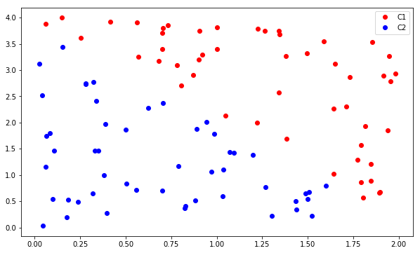

```python
m = 100
w = np.array([[-4], [2], [1]])
X = np.hstack([np.ones([m,1]), 2*np.random.rand(m,1), 4*np.random.rand(m,1)])

w = np.asmatrix(w)
X = np.asmatrix(X)

y = (np.exp(X*w)/(1+np.exp(X*w))) > 0.5

C1 = np.where(y == True)[0]
C2 = np.where(y == False)[0]

y = np.empty([m,1])
y[C1] = 1
y[C2] = 0
y = np.asmatrix(y)

plt.figure(figsize = (10,6))
plt.plot(X[C1,1], X[C1,2], 'ro', label='C1')
plt.plot(X[C2,1], X[C2,2], 'bo', label='C2')
plt.legend()
plt.show()
```

$$ \begin{align*} \ell(\omega) &= \log \mathscr{L} = \sum\limits_{i=1}^{q}{\log p_i} + \sum\limits_{i=q+1}^{m}{\log(1 - p_i)} \\ & = \sum\limits_{i=1}^{q}{\log \frac{\exp\left(\omega^T x_i\right)}{1 + \exp \left(\omega^T x_i \right)}} + \sum\limits_{i=q+1}^{m}{\log \frac{1}{1+\exp \left(\omega^T x_i \right)}} \\ &= \sum\limits_{i=1}^{q}{\left(\omega^T x_i\right)} - \sum\limits_{i=1}^{m}{\log \left(1+\exp \left(\omega^T x_i \right) \right)} \end{align*} $$

Refer to [cvx functions](http://www.cvxpy.org/en/latest/tutorial/functions/)

- scalar function: `cvx.sum_entries(x)` = $\sum_{ij} x_{ij}$
- elementwise function: `cvx.logistic(x)` = $\log \left(1+e^{x} \right)$

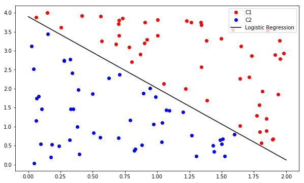

```python
import cvxpy as cvx

w = cvx.Variable(3, 1)

obj = cvx.Maximize(y.T*X*w - cvx.sum_entries(cvx.logistic(X*w)))
prob = cvx.Problem(obj).solve()

w = w.value

xp = np.linspace(0,2,100).reshape(-1,1)
yp = - w[1,0]/w[2,0]*xp - w[0,0]/w[2,0]

plt.figure(figsize = (10,6))
plt.plot(X[C1,1], X[C1,2], 'ro', label='C1')
plt.plot(X[C2,1], X[C2,2], 'bo', label='C2')
plt.plot(xp, yp, 'k', label='Logistic Regression')
plt.legend()
plt.show()
```

## 3.4. Multiclass Classification

- Generalization to more than 2 classes is straightforward
  - one vs. all (one vs. rest)
  - one vs. one
- Using the soft-max function instead of the logistic function (refer to [UFLDL Tutorial](http://ufldl.stanford.edu/tutorial/supervised/SoftmaxRegression/))
  - see them as probability

$$P\left(y = k \mid x,\omega\right) = \frac{\exp{\left( \omega_k^T x \right) }}{\sum_k \exp{\left(\omega_k^T x \right)}} \in [0,1]$$

- We maintain a separator weight vector $\omega_k$ for each class $k$

```python
%%javascript
$.getScript('https://kmahelona.github.io/ipython_notebook_goodies/ipython_notebook_toc.js')
```